# R for Business Analytics

http://www.therbootcamp.com

November 2018 @ Geneva

## Synopsis

R is one of the most popular and fastest growing languages for statistical analyses and business analytics. Unlike proprietary software such as SPSS, SAS, or MatLab, R is free, open source, and gives you access to the latest statistical techniques from its unparalleled community of developers. For these reasons, R is often the language of choice for researchers and data scientists working in companies such as Google, Apple, and Facebook. This course is designed to show anyone how to process, analyze, and display business-relevant data using R from the ‘ground-up’. Starting from day one, we will work with hands-on exercises and real data in front of the computer to help you ‘learn by doing’. The course takes place over 3 days, each covering a different use of R for business analytics. In the first day, you will learn the essentials of the R language and programming. In the second day, you will learn how to work with data, combine multiple data sets and conduct common statistical analyses, including t-tests, ANOVAs, and regression. In the third day, you will learn how use R to make striking visualisations and produce elegant reports communicating the results of your analyses.

## Materials

#### [Get datasets](https://raw.githubusercontent.com/therbootcamp/BaselRBootcamp_2018July/master/_sessions/_data/baselrbootcamp_data.zip)

|  | Day 1 Essentials | Day 2 Statistics | Day 3 Reporting |
| --- | --- | --- | --- |
| 0 | Welcome! slides | Recap I slides | Recap II slides |
| 1 | Intro to R slides, practical | Wrangling slides, practical | Plotting slides, practical |
| 2 | Objects & Functions slides, practical | Wrangling II slides (tba), practical (tba) | Plotting II slides (tba), practical (tba) |
| 3 | Data I/O slides, practical | Statistics slides, practical | Dynamic Reports slides, practical |

## Schedule

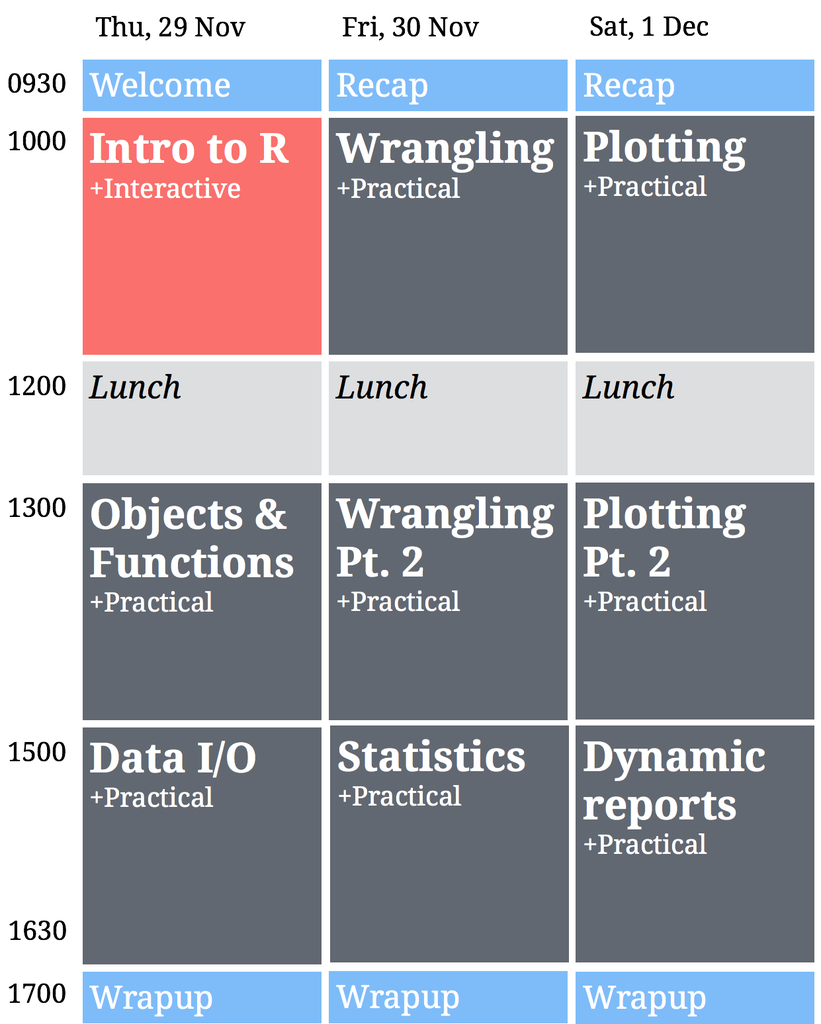